# RMarkdown demo

Rudolf Schlechter

2024-05-16

## First things first

### Why do we care about R Markdown?

Scripts can be messy and difficult to follow when not enough information is provided. However, *too much* text in a script can be distracting!

R Markdown is a simple formatting syntax. The main purpose is to connect data analysis with documentation. For that, the most simple way is to combine **markdown** (md) with **R** syntax.

`.Rmd file` -> `dynamic document` -> `reproducible research`

# Header 1

## Header 2

### Header 3

#### Header 4

##### Header …

Plain text.

You can use *italics* and **bold**.

superscript<sup>s</sup> and subscript<sub>s</sub>.

strikethrough

- Unordered list
- Itemised
  - Item 1
  - Item 2
1. Ordered list

`verbatim code`

> block quote

equation: $e^{i/pi} + 1 = 0$

Table

[link](https://rmarkdown.rstudio.com)

| Component | Amount | Unit |
| --- | --- | --- |
| Buffer | 10 | $\mu$L |
| Primer Fwd | 1.5 | $\mu$L |
| Primer Fwd | 1.5 | $\mu$L |
| Water | 6 | $\mu$L |
| DNA | 1.0 | $\mu$L |

## Workflow

1. Open new .Rmd file
2. Embed code
3. Write text
4. Set output format (header)
5. Save and render
6. Share!

## Let’s work with a dataset

To insert a code chunk, try `alt + ctrl + I` or `option + cmd + I`.

```r
message <- c(print('Hello world!'))
```

```
## [1] "Hello world!"
```

I want to write Hello world!.

Let’s install the [penguins data set](https://allisonhorst.github.io/palmerpenguins/)

```r
install.packages("palmerpenguins")
```

Now we load the package and dataset

```r
library(palmerpenguins)
data(package = 'palmerpenguins')
```

### Data summary

```r
str(penguins)
```

```
## tibble [344 × 8] (S3: tbl_df/tbl/data.frame)
##  $ species          : Factor w/ 3 levels "Adelie","Chinstrap",..: 1 1 1 1 1 1 1 1 1 1 ...
##  $ island           : Factor w/ 3 levels "Biscoe","Dream",..: 3 3 3 3 3 3 3 3 3 3 ...
##  $ bill_length_mm   : num [1:344] 39.1 39.5 40.3 NA 36.7 39.3 38.9 39.2 34.1 42 ...
##  $ bill_depth_mm    : num [1:344] 18.7 17.4 18 NA 19.3 20.6 17.8 19.6 18.1 20.2 ...
##  $ flipper_length_mm: int [1:344] 181 186 195 NA 193 190 181 195 193 190 ...
##  $ body_mass_g      : int [1:344] 3750 3800 3250 NA 3450 3650 3625 4675 3475 4250 ...
##  $ sex              : Factor w/ 2 levels "female","male": 2 1 1 NA 1 2 1 2 NA NA ...
##  $ year             : int [1:344] 2007 2007 2007 2007 2007 2007 2007 2007 2007 2007 ...
```

Looking at the structure of the data, we have 3 species of penguins: Adelie, Chinstrap, Gentoo, found in the islands of Biscoe, Dream, Torgersen.

```r
head(penguins)
```

```
## # A tibble: 6 × 8
##   species island    bill_length_mm bill_depth_mm flipper_length_mm body_mass_g
##   <fct>   <fct>              <dbl>         <dbl>             <int>       <int>
## 1 Adelie  Torgersen           39.1          18.7               181        3750
## 2 Adelie  Torgersen           39.5          17.4               186        3800
## 3 Adelie  Torgersen           40.3          18                 195        3250
## 4 Adelie  Torgersen           NA            NA                  NA          NA
## 5 Adelie  Torgersen           36.7          19.3               193        3450
## 6 Adelie  Torgersen           39.3          20.6               190        3650
## # ℹ 2 more variables: sex <fct>, year <int>
```

The dataset contains data of 344 penguins, and each entry has phenotypic data such as bill length (mm), bill depth (mm), flipper length (mm), body mass (g), sex (male/female), and year of entry.

```r
# Determine the mean value of every parameter from each penguins, grouped by species, island and sex
penguins %>%
  na.exclude %>%
  group_by(species, island, sex) %>%
  summarise(bill_length = mean(bill_length_mm),
            bill_depth = mean(bill_depth_mm),
            flipper_length = mean(flipper_length_mm),
            body_mass = mean(body_mass_g))
```

```
## # A tibble: 10 × 7
## # Groups:   species, island [5]
##    species   island    sex    bill_length bill_depth flipper_length body_mass
##    <fct>     <fct>     <fct>        <dbl>      <dbl>          <dbl>     <dbl>
##  1 Adelie    Biscoe    female        37.4       17.7           187.     3369.
##  2 Adelie    Biscoe    male          40.6       19.0           190.     4050
##  3 Adelie    Dream     female        36.9       17.6           188.     3344.
##  4 Adelie    Dream     male          40.1       18.8           192.     4046.
##  5 Adelie    Torgersen female        37.6       17.6           188.     3396.
##  6 Adelie    Torgersen male          40.6       19.4           195.     4035.
##  7 Chinstrap Dream     female        46.6       17.6           192.     3527.
##  8 Chinstrap Dream     male          51.1       19.3           200.     3939.
##  9 Gentoo    Biscoe    female        45.6       14.2           213.     4680.
## 10 Gentoo    Biscoe    male          49.5       15.7           222.     5485.
```

We can make a nicer table using `kable` from the `knitr` package. Also we can get rid of the message with local options (set `message = FALSE`) or move it to the global options.

```r
penguins %>%
  na.exclude %>%
  group_by(species, island, sex) %>%
  summarise(bill_length = mean(bill_length_mm),
            bill_depth = mean(bill_depth_mm),
            flipper_length = mean(flipper_length_mm),
            body_mass = mean(body_mass_g)) %>%
  knitr::kable()
```

| species | island | sex | bill_length | bill_depth | flipper_length | body_mass |
| --- | --- | --- | --- | --- | --- | --- |
| Adelie | Biscoe | female | 37 | 18 | 187 | 3369 |
| Adelie | Biscoe | male | 41 | 19 | 190 | 4050 |
| Adelie | Dream | female | 37 | 18 | 188 | 3344 |
| Adelie | Dream | male | 40 | 19 | 192 | 4046 |
| Adelie | Torgersen | female | 38 | 18 | 188 | 3396 |
| Adelie | Torgersen | male | 41 | 19 | 195 | 4035 |
| Chinstrap | Dream | female | 47 | 18 | 192 | 3527 |
| Chinstrap | Dream | male | 51 | 19 | 200 | 3939 |
| Gentoo | Biscoe | female | 46 | 14 | 213 | 4680 |
| Gentoo | Biscoe | male | 49 | 16 | 222 | 5485 |

## Exploratory analysis

R Markdown is useful to add those extra steps that might not end up in your final manuscript, such as your exploratory analysis!

Let’s evaluate if the data is normally distributed by looking at histograms

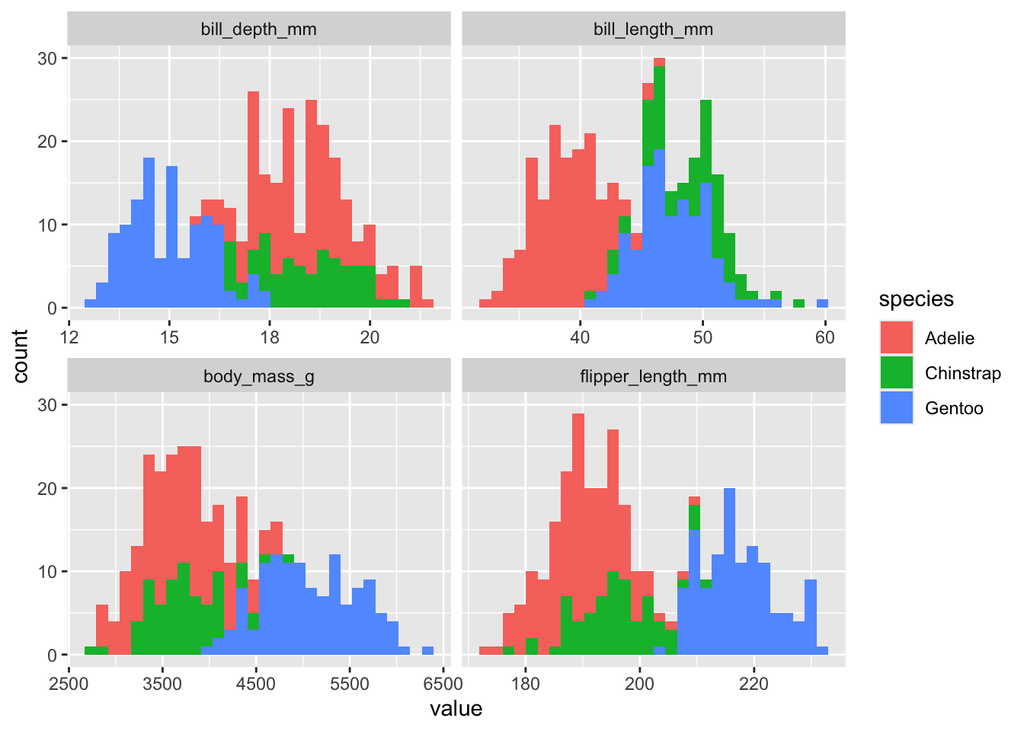

```r
# Histogram
penguins %>%
  pivot_longer(cols = c(bill_length_mm, bill_depth_mm, flipper_length_mm, body_mass_g)) %>%
  ggplot(aes(x = value, fill = species)) +
  facet_wrap(~name, scales = "free_x")+
  geom_histogram()
```

We can analyse a bit further the body mass of the different species of penguins.

## Linear model

A linear model is a regression analysis in which a response variable can be described as a function of one or more predictors. In R, we express it as `y ~ x`.

In our case, we will use body mass as our response variable and we want to see how the different species contribute to the variation in weight among penguins.

```r
# Model definition
mod0 = lm(body_mass_g ~ 1, data = penguins) # Null model
mod1 = lm(body_mass_g ~ species, data = penguins)

# Is our model better than the null model?
anova(mod0, mod1)
```

```
## Analysis of Variance Table
##
## Model 1: body_mass_g ~ 1
## Model 2: body_mass_g ~ species
##   Res.Df       RSS Df Sum of Sq   F Pr(>F)
## 1    341 219307697
## 2    339  72443483  2 146864214 344 <2e-16 ***
## ---
## Signif. codes:  0 '***' 0.001 '**' 0.01 '*' 0.05 '.' 0.1 ' ' 1
```

```r
# Model Summary
summary(mod1)
```

```
##
## Call:
## lm(formula = body_mass_g ~ species, data = penguins)
##
## Residuals:
##     Min      1Q  Median      3Q     Max
## -1126.0  -333.1   -33.1   316.9  1224.0
##
## Coefficients:
##                  Estimate Std. Error t value Pr(>|t|)
## (Intercept)        3700.7       37.6   98.37   <2e-16 ***
## speciesChinstrap     32.4       67.5    0.48     0.63
## speciesGentoo      1375.4       56.1   24.50   <2e-16 ***
## ---
## Signif. codes:  0 '***' 0.001 '**' 0.01 '*' 0.05 '.' 0.1 ' ' 1
##
## Residual standard error: 462 on 339 degrees of freedom
##   (2 observations deleted due to missingness)
## Multiple R-squared:  0.67,   Adjusted R-squared:  0.668
## F-statistic:  344 on 2 and 339 DF,  p-value: <2e-16
```

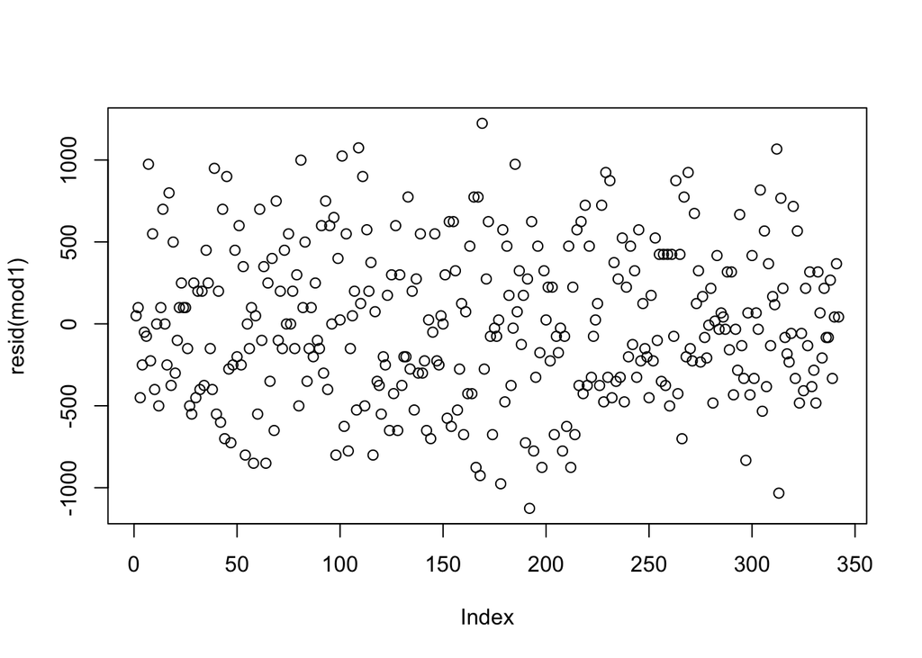

```r
# Residuals
plot(resid(mod1))
```

```r
# Extract some the data from the model
df.mod1 <- tidy(mod1) %>%
  mutate(species = levels(penguins$species),
         mean_body_mass = ifelse(term == "(Intercept)",
                                 estimate,
                                 estimate[species == "Adelie"] + estimate))
```

We can extract information from our model and use inline code. For example, we have now learned that the weight of species Adelie is lower (mean = 3700.66 g) than that of species Gentoo (mean = 5076.02 g), with a *p*-value = 5.42^{-77} and an adjusted *R*<sup>2</sup> = 66.77%.

Let’s plot our results:

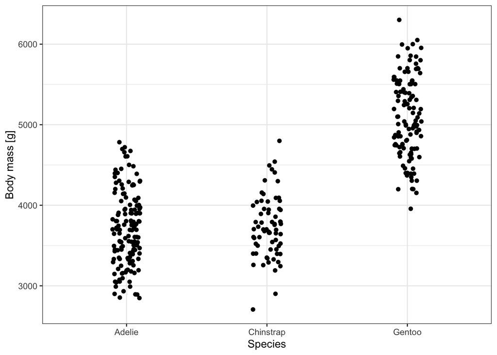

```r
penguins %>%
  na.exclude %>%
  ggplot(aes(x = species, y = body_mass_g))+
  geom_jitter(width = 0.1)+
  theme_bw()+
  labs(x = "Species", y = "Body mass [g]")
```

We can include the means extracted from the model:

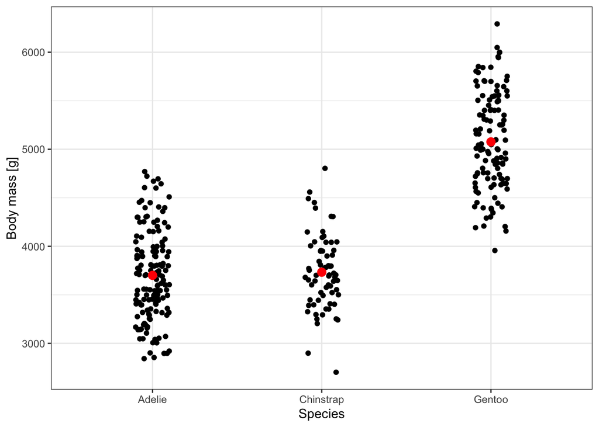

```r
penguins %>%
  na.exclude %>%
  ggplot(aes(x = species, y = body_mass_g))+
  geom_jitter(width = 0.1)+
  # Add a red dot representing the mean of each group
  geom_point(data = df.mod1, aes(x = species, y = mean_body_mass),
             color = "red",
             size = 3)+
  theme_bw()+
  labs(x = "Species", y = "Body mass [g]")
```